# Proyecto Fin de Master

Lucía Rico Cuéllar

08 de julio de 2017

## Introducción

El propósito de este proyecto es aplicar varios modelos predictivos a un conjunto de series temporales de 1990 a 2016 (divididas en conjunto de entrenamiento y testeo) y encontrar el modelo óptimo que minimiza el error en cada caso. Para ello, primero estudiaremos una de las series temporales (elegida al azar) con detalle y, posteriormente, extenderemos el estudio al resto de series.

Además se va a representar todo con gráficos interactivos y, posteriormente en otro documento anexo, representaremos mediante una aplicación interactiva con la herramienta Shiny la predicción para cada serie del 2017 y 2018 según los modelos predictivos utilizados.

## Lectura y limpieza de datos

Vamos a usar los datos de series mensuales de tráfico en autopistas estatales de peaje, proporcionados por el Ministerio de Fomento del Gobierno de España [en su web](http://www.fomento.gob.es/BE/?nivel=2&orden=06000000) para modelar.

Haremos tres funciones de lectura y limpieza para sacar la información mensual y anual de los ficheros de las 28 autopistas, que tienen estructuras similares (excepto el fichero de los datos globales “Total.”, que no lo usaremos).

Usaremos los datos mensuales obtenidos de la limpieza para construir las series temporales.

Usaremos los datos anuales solo para calcular el promedio de IMD (Intensidad Medida Diaria) en los datos de test (lo veremos en el último).

Los datos de cada una de las 28 autopistas los hemos almacenado en formato .csv en la carpeta dat.

Estas serían las 3 funciones del archivo `../src/funciones.R`:

*`lee_TODAS_autopista` :función que lee todos los ficheros .csv almacenados en la carpeta dat y devuelve un data frame con todos los datos mensuales.

*`lee_autopista` :función que lee un solo .csv de una sola autopista seleccionada y devuelve un data frame con todos los datos mensuales. Es como la anterior pero para una sola autopista.

*`lee_autopista_anual`: función que lee un solo .csv y devuelve los datos anuales. Tal como se ha indicado, solo la usaremos para calcular el IMD promedio.

El fichero de cada autopista contiene datos para hacer 2 tablas, una de datos totales y otra de datos mensuales, ambas con información de la longitud de la autopista, IMD de vehículos pesados y totales y variaciones respecto al año anterior de los IMDs.

Vamos a quedarnos a las salidas de las funciones mencionadas solo con los datos de fechas e IMD_total (IMD es una media de vehículos mensuales, tanto pesados como ligeros, promediados por los días que tiene cada mes). Lo que intentaremos predecir los próximos años será este IMD.

El resto de columnas que descartamos, tienen dependencia lineal con esta columna (variaciones e IMD_pesados), por lo que no aportan información extra. Tampoco vamos a considerar la longitud de la autopista.

Usaremos el fichero `../dat/nombres_autopistas.txt` de la carpeta dat, que contiene los nombres de todas las 28 autopistas , en los que se ha conservado el código numérico que las identifica en la web del Ministerio por si se necesitara para cualquier revisión futura:

| 06020101_montmelo_la_junquera |
| --- |
| 06020102_barcelona_tarragona_A_7 |
| 06020103_montmelo_papiol_A_7 |
| 06020201_zaragoza_mediterraneo_A_2 |
| 06020202_villalba_adanero_A_6 |
| 06020203_sevilla_cadiz |
| 06020301_tarragona_valencia_A_7 |
| 06020302_valencia_alicante_A_7 |
| 06020303_ferrol_fr_portuguesa_A_9 |
| 06020401_bilbao_zaragoza_A_68 |
| 06020402_burgos_arminon_A_1 |
| 06020403_leon_campomanes_A_66 |
| 06020501_malaga_guadiaro |
| 06020502_alicante_cartagena |
| 06020503_avila_villacastin |
| 06020601_leon_astorga |
| 06020602_santiago_alto_sto_domingo |
| 06020603_segovia_san_rafael |
| 06020701_madrid_guadalajara |
| 06020702_madrid_arganda |
| 06020703_madrid_navalcarnero |
| 06020801_madrid_ocana |
| 06020802_eje_aeropuerto |
| 06020803_ocana_la_roda |
| 06020901_madrid_toledo |
| 06020902_cartagena_vera |
| 06020903_circunvalacion_alicante |
| 06021001_alto_de_las_pedrizas_malaga |

### Eliminación de falsos outliers

Hacemos una inspección visual para detectar posibles “falsos outliers”, valores muy bajos de IMD que realmente no son outliers, sino erratas por error de grabado/lectura de los datos acabados en “.000”: Hay veces que el “.000” guardado representa “unidad, decena y centena” de un número entero y otras veces representa decimales nulos de un número decimal, y en la lectura ambos casos son tratados igual por error y los .000 se eliminan en el primer caso incorrectamente y en el segundo correctamente. Encontramos algunos leídos incorrectamente y los corregimos:

| Mes_numeric | IMD_total | nombre |
| --- | --- | --- |
| sep. 2004 | 45 | 06020101_montmelo_la_junquera |
| jun. 1990 | 12 | 06020302_valencia_alicante_A_7 |
| jun. 1994 | 12 | 06020302_valencia_alicante_A_7 |
| jun. 2003 | 23 | 06020303_ferrol_fr_portuguesa_A_9 |
| jul. 2004 | 22 | 06020502_alicante_cartagena |

Los hemos corregido.

### Eliminación de outliers

Detectamos un outlier en la autopista “06020203_sevilla_cadiz” y lo corregimos aproximando por interpolación lineal con la función `na.intepolation` del paquete `imputeTS`:

[interactive chart not shown]

Corregido:

[interactive chart not shown]

## Estudio de una autopista al azar sin aplicar logaritmos

Vamos a basarnos para los estudios en el libro “Forecasting: principles and practice” de Rob J Hyndman y George Athanasopoulos [en su web](https://www.otexts.org/fpp/1) para predecir el `IMD_total` de los próximos periodos.

Escogemos una autopista al azar: `06020101_montmelo_la_junquera`

Vamos a analizarla en detalle con y sin aplicar logaritmos en base 10. En cada caso (con y sin log) aplicaremos 2 modelos: ETS y ARIMA y a continuación aplicaremos la función forecast para predecir. Finalmente evaluaremos y compararemos los errores para elegir el mejor modelo.

Creo serie temporal para esa autopista.

Para poder inspeccionar gráficamente los valores y hacer zoom representamos con paquete highcharter:

[interactive chart not shown]

Resumen de estadísticas básicas de los datos:

```
##      Index       xts_mensual
##  Min.   :1990   Min.   :19110
##  1st Qu.:1997   1st Qu.:29142
##  Median :2004   Median :36706
##  Mean   :2004   Mean   :37530
##  3rd Qu.:2010   3rd Qu.:43718
##  Max.   :2017   Max.   :68198
```

### Descomposición estacional

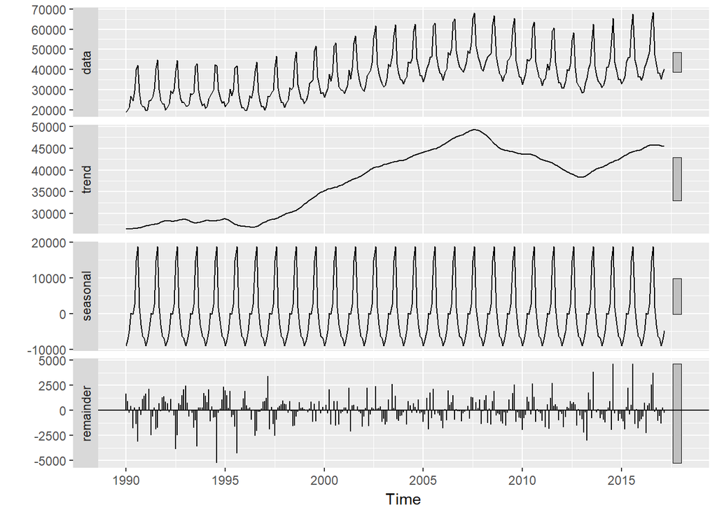

Lo más destacable es la clara estacionalidad anual. Últimos años sin tendencia creciente ni decreciente. Hay ciclos de subida y bajada.

### Selección de conjuntos de entrenamiento (train) y testeo (test)

Seleccionamos 1 ventana de la serie temporal para train y otra para test. Tenemos datos completos de 27 años (desde 1990 a 2016 ambos inclusive).

Se hace una primera prueba y se dejan los 5 últimos años para test (son aproximadamente el 20% de los datos) y se observa gráficamente que para todos los modelos se incrementa el error a partir del tercer año, por lo que se reduce el intervalo de test a 2 años.

NOTA: No se cree relevante presentar en este reporte los resultados de las pruebas para 5 años, pero si así se requisiera se adjuntan en otro fichero en la misma carpeta res `../res/ANALISIS_DESCARTE_de_intervalos_test_prediccion_5años.Rmd`.

Representamos los conjuntos de test y train:

[interactive chart not shown]

### Modelado exponencial ETS y predicción

Vamos a usar el suavizado exponencial, que se basa en la descripción de la tendencia, cliclo y estacionalidad la serie. Para ellos usaremos la función `ets()` y luego le aplicamos la función `forecast()` para predecir un intervalo de 2 años (años 2015 y 2016 completos):

```
## ETS(M,Ad,M)
##
## Call:
##  ets(y = train)
##
##   Smoothing parameters:
##     alpha = 0.2926
##     beta  = 0.0113
##     gamma = 0.1885
##     phi   = 0.976
##
##   Initial states:
##     l = 26017.4934
##     b = 130.5668
##     s=0.8186 0.8164 0.8964 1.0698 1.5608 1.4485
##            1.0647 0.9607 0.9981 0.8561 0.7682 0.7416
##
##   sigma:  0.0384
##
##      AIC     AICc      BIC
## 6074.223 6076.657 6140.891
```

La predicción:

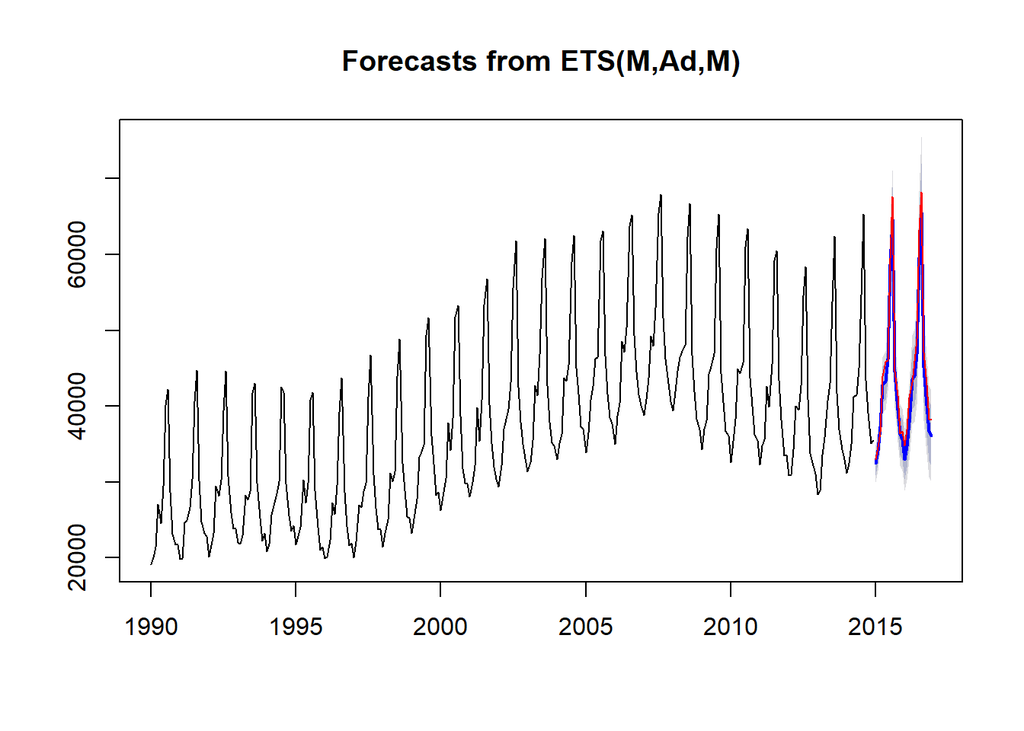

Dibujo el gráfico anterior de manera interactiva:

[interactive chart not shown]

Precisión:

Se analizará en un apartado posterior con más detalle, comparando todos los modelos:

```
##                     ME     RMSE      MAE        MPE     MAPE      MASE
## Training set   -1.1779 1536.716 1137.553 0.07218132 3.013092 0.5936459
## Test set     1504.2500 1905.121 1605.455 3.27523085 3.529541 0.8378259
##                    ACF1 Theil's U
## Training set 0.09696071        NA
## Test set     0.06451700 0.2893606
```

### Modelado ARIMA y predicción

Vamos a usar el modelado ARIMA basado en la descripción de autocorrelación (suma de un modelado de media móvil (MA) y uno de autorregresión (AR)).

Lo aplicaremos mediante la función `auto.arima()` para modelar la serie y luego le aplicamos la función `forecast()` para predecir un intervalo de 2 años (años 2015 y 2016 completos):

```
## Series: train
## ARIMA(2,1,0)(2,1,2)[12]
##
## Coefficients:
##           ar1      ar2     sar1     sar2    sma1     sma2
##       -0.7897  -0.2801  -0.5312  -0.1623  0.0369  -0.3680
## s.e.   0.0605   0.0591   0.1319   0.0973  0.1280   0.1049
##
## sigma^2 estimated as 1633281:  log likelihood=-2460.95
## AIC=4935.9   AICc=4936.31   BIC=4961.52
```

El modelo óptimo es un ARIMA(2,1,0)(2,1,2)[12]:

*La componente no estacional tiene orden 2 en la parte AR (autorregresiva), orden 0 en la parte AM (media móvil) y grado 1 de diferencia.

*La componente estacional tiene orden 2 en la parte AR, orden 2 en la AM y grado 1 de diferencia.Tiene estacionalidad anual (12 meses)

La predicción:

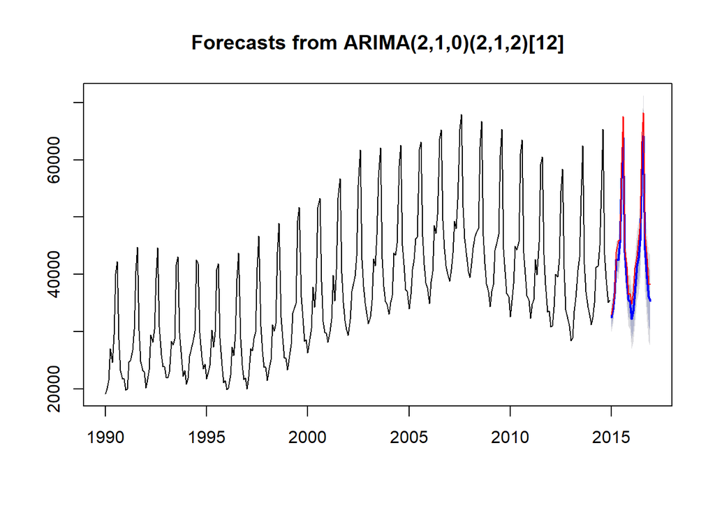

Dibujo el gráfico anterior de manera interactiva:

[interactive chart not shown]

Precisión: Se analizará en un apartado posterior con más detalle, comparando todos los modelos:

```
##                       ME     RMSE       MAE        MPE     MAPE      MASE
## Training set   -5.058141 1236.867  939.0563 -0.1128318 2.580322 0.4900578
## Test set     2414.450599 2795.501 2420.8877  5.2560467 5.273623 1.2633694
##                       ACF1 Theil's U
## Training set -0.0005854411        NA
## Test set      0.2960422184 0.4232369
```

Analizando los residuos del modelo ARIMA: No se ve correlación, la distribución de residuos es normal (aunque un poco ancha) y pasa el test de de portmanteau (p-valor próximo a 1), luego los intervalos de predicción son fiables.

Distribución de los residuos:

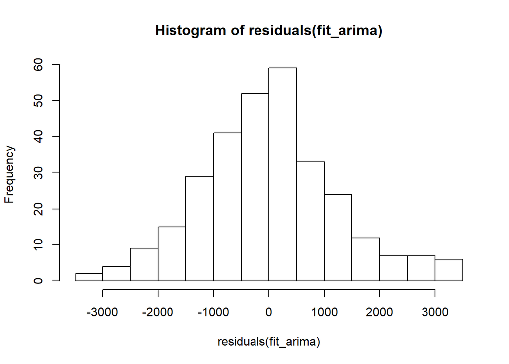

Correlación de los residuos:

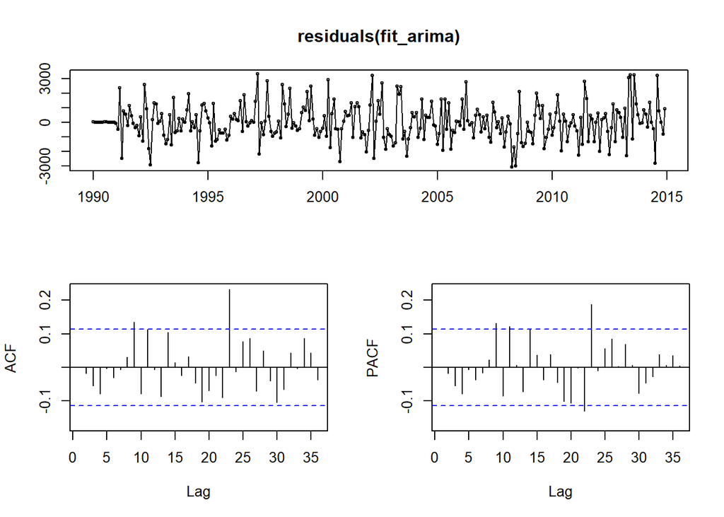

Test de de portmanteau:

```
##
##  Box-Ljung test
##
## data:  residuals(fit_arima)
## X-squared = 0.00010385, df = 1, p-value = 0.9919
```

## Estudio de una autopista al azar aplicando logaritmos

Repetimos lo mismo que en el apartado anterior, pero aplicando previamente logaritmo en base 10 a la misma serie temporal.

Creo serie temporal:

[interactive chart not shown]

Resumen de estadísticas básicas de los datos:

```
##    Min. 1st Qu.  Median    Mean 3rd Qu.    Max.
##   4.280   4.465   4.560   4.555   4.640   4.830
```

### Descomposición estacional

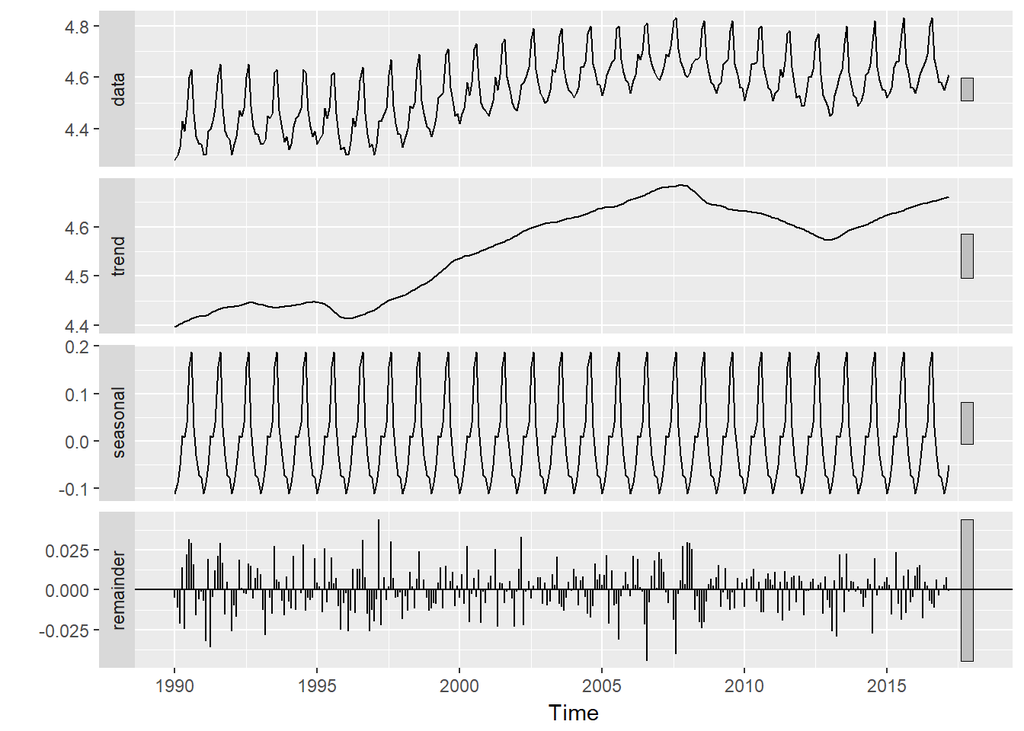

En este caso sigue siendo estacional y cíclica, y parece que la tendencia si que es creciente y no constante.

### Selección de conjuntos de entrenamiento (train) y testeo (test)

Igualmente elijo los 2 años (2015 y 2016 completos):

[interactive chart not shown]

### Modelado exponencial ETS y predicción

```
## ETS(M,N,A)
##
## Call:
##  ets(y = train_log)
##
##   Smoothing parameters:
##     alpha = 0.3719
##     gamma = 0.1351
##
##   Initial states:
##     l = 4.4
##     s=-0.0731 -0.0742 -0.0342 0.0403 0.2007 0.1675
##            0.0363 -0.0035 0.0095 -0.057 -0.0981 -0.1142
##
##   sigma:  0.0038
##
##       AIC      AICc       BIC
## -701.4051 -699.7150 -645.8484
```

El modelo óptimo es ETS(M,N,A): error multiplicativo, sin tendencia y estacionalidad aditiva.

La predicción:

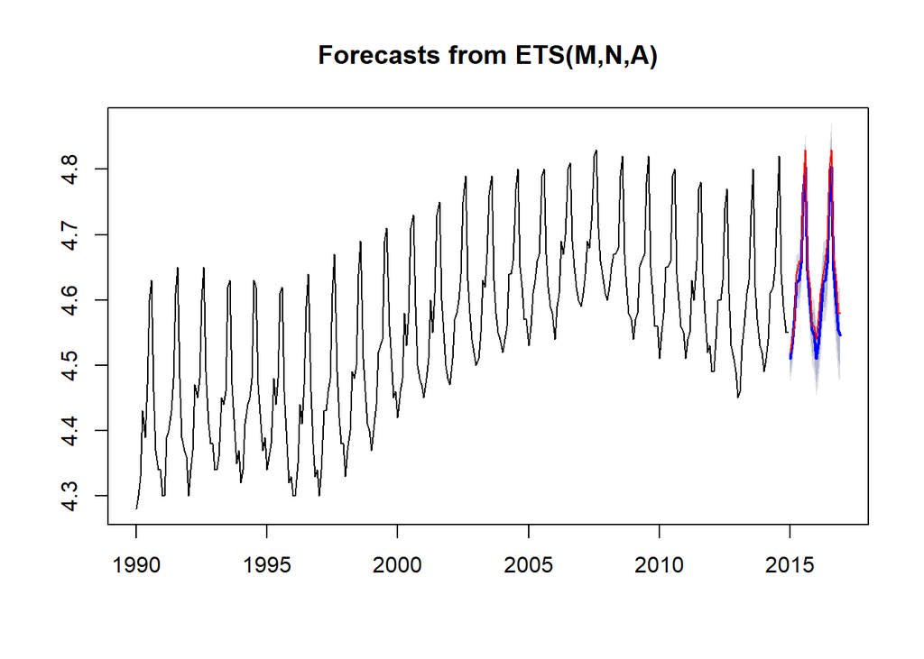

Dibujo el gráfico anterior de manera interactiva:

[interactive chart not shown]

Precisión: Se analizará en un apartado posterior con más detalle, comparando todos los modelos:

```
##                       ME       RMSE        MAE        MPE      MAPE
## Training set 0.001906358 0.01707902 0.01360497 0.04232872 0.2987072
## Test set     0.021325767 0.02513500 0.02202149 0.45866124 0.4739184
##                   MASE        ACF1 Theil's U
## Training set 0.5839391 -0.01551366        NA
## Test set     0.9451849  0.32576410 0.3820925
```

### Modelado ARIMA y predicción

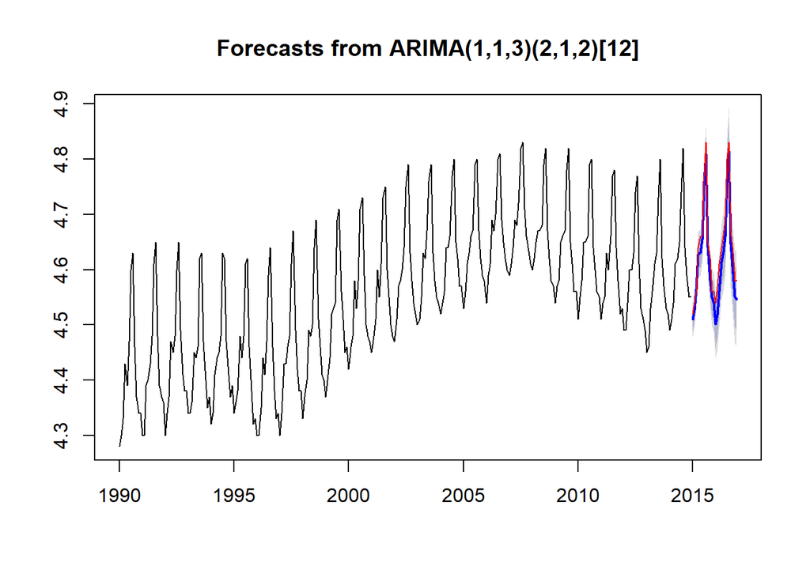

Dibujo el gráfico anterior de manera interactiva:

[interactive chart not shown]

Analizando los residuos del modelo ARIMA: No se ve correlación, la distribución de residuos es normal y pasa el test de de portmanteau, luego los intervalos de predicción son fiables

Correlación de los residuos:

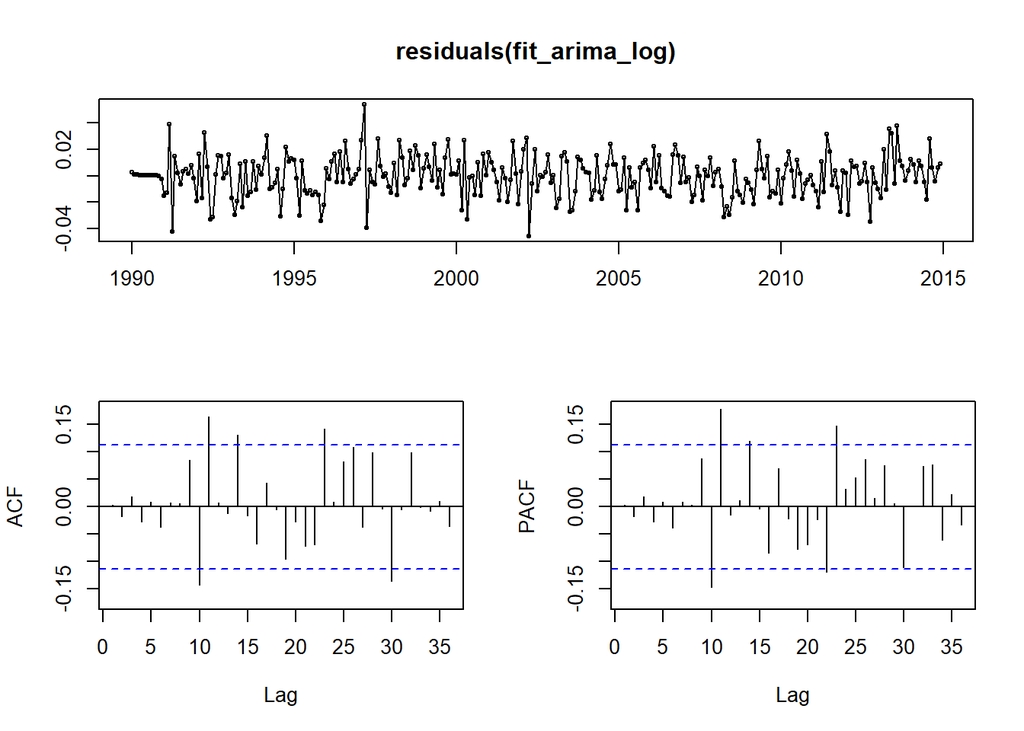

Distribución de los residuos:

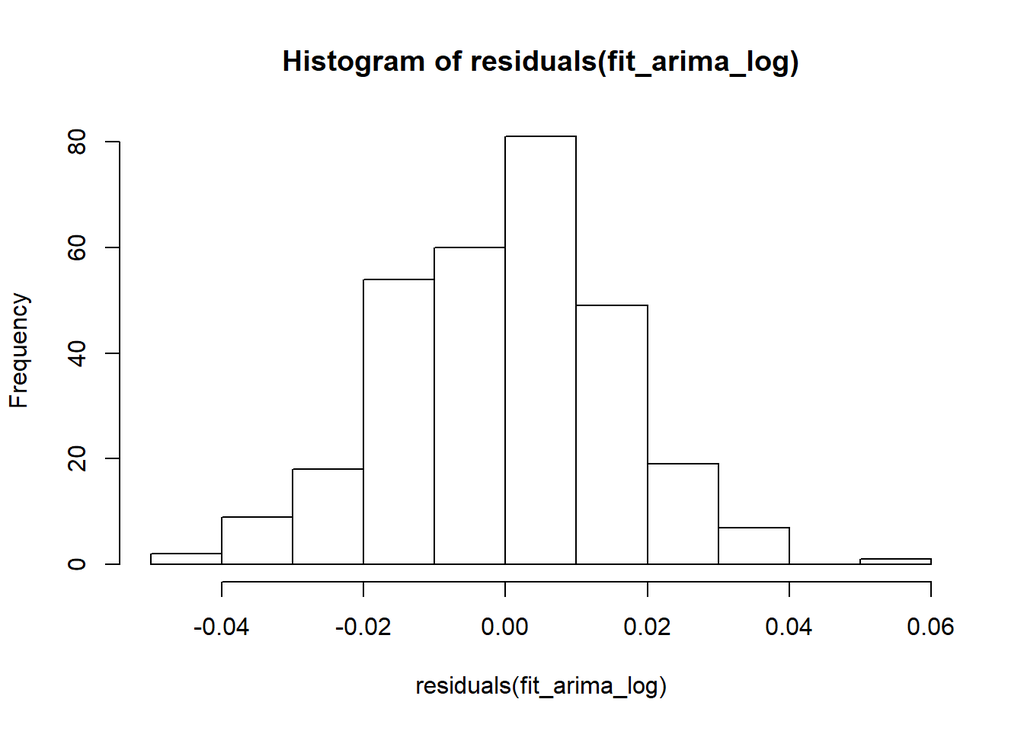

Test de de portmanteau

```
##
##  Box-Ljung test
##
## data:  residuals(fit_arima_log)
## X-squared = 0.003446, df = 1, p-value = 0.9532
```

Precisión: Se analizará en un apartado posterior con más detalle, comparando todos los modelos:

```
##                         ME       RMSE        MAE          MPE      MAPE
## Training set -0.0003073347 0.01561168 0.01223327 -0.006610854 0.2688996
## Test set      0.0236472678 0.02745883 0.02403534  0.509921325 0.5184316
##                   MASE        ACF1 Theil's U
## Training set 0.5250642 0.003372301        NA
## Test set     1.0316211 0.391115552 0.4192395
```

## Comparación de los errores de la autopista analizada

Construyo una tabla comparativa con los errores de todos los modelos.

Nos quedamos los datos de test para comparar solo esos resultados, pues son los que más error tienen (respecto a los de train).

Vamos a hacer una función que construye la tabla comparativa. Le pasamos a la función las prediciones obtenidas y el promedio de los datos de test (para calcular también el error porcentual dividiendo error MAE/RMSE entre el promedio de los datos de test):

| RMSE | MAE | modelo | RMSE_porc | MAE_porc |
| --- | --- | --- | --- | --- |
| 1905.12 | 1605.45 | ETS | 4.25 | 3.58 |
| 2795.50 | 2420.89 | ARIMA | 6.23 | 5.39 |
| 2741.34 | 2350.06 | ETS_log | 6.11 | 5.24 |
| 2799.52 | 2483.13 | ARIMA_log | 6.24 | 5.53 |

El modelo óptimo para esta serie sería el ETS sin aplicar logaritmos (menor MAE)

## Extensión del estudio al resto de autopistas

Por analogía, generamos un código que va a calcular los errores MAE/ RMSE resultantes de aplicar los 4 modelos (ETS/ ARIMA con y sin logaritmos) a cada autopista con un intervalo predictivo de 2 años (próximos 2015 y 2016). Esta sería la tabla resultante: NOTA: Esta ejecución tarda unos 15-18 minutos aproximadamente, por lo que se facilita en la carpeta dat una copia del resultado `../dat/comparando_TODOS.txt`, y vamos a trabajar con ella en lo que sigue, pero puede ejecutarse desde aquí descomentando la linea `source("../src/codigo_genera_comparando_TODOS.R")`.

| RMSE | MAE | modelo | RMSE_porc | MAE_porc | nombre |
| --- | --- | --- | --- | --- | --- |
| 1905.12 | 1605.45 | ETS | 4.25 | 3.58 | 06020101_montmelo_la_junquera |
| 2795.50 | 2420.89 | ARIMA | 6.23 | 5.39 | 06020101_montmelo_la_junquera |
| 2741.34 | 2350.06 | ETS_log | 6.11 | 5.24 | 06020101_montmelo_la_junquera |
| 2799.52 | 2483.13 | ARIMA_log | 6.24 | 5.53 | 06020101_montmelo_la_junquera |
| 3655.64 | 3133.74 | ETS | 7.15 | 6.13 | 06020102_barcelona_tarragona_A_7 |
| 6007.42 | 5416.01 | ARIMA | 11.74 | 10.59 | 06020102_barcelona_tarragona_A_7 |
| 2896.35 | 2500.56 | ETS_log | 5.66 | 4.89 | 06020102_barcelona_tarragona_A_7 |
| 6100.67 | 5503.94 | ARIMA_log | 11.92 | 10.76 | 06020102_barcelona_tarragona_A_7 |
| 4347.67 | 3721.51 | ETS | 4.04 | 3.46 | 06020103_montmelo_papiol_A_7 |
| 6190.01 | 4740.10 | ARIMA | 5.75 | 4.41 | 06020103_montmelo_papiol_A_7 |
| 3899.25 | 3311.63 | ETS_log | 3.62 | 3.08 | 06020103_montmelo_papiol_A_7 |
| 3494.53 | 2689.64 | ARIMA_log | 3.25 | 2.50 | 06020103_montmelo_papiol_A_7 |
| 1592.36 | 1348.99 | ETS | 14.39 | 12.19 | 06020201_zaragoza_mediterraneo_A_2 |
| 2161.31 | 1921.86 | ARIMA | 19.53 | 17.37 | 06020201_zaragoza_mediterraneo_A_2 |
| 1906.17 | 1629.48 | ETS_log | 17.22 | 14.72 | 06020201_zaragoza_mediterraneo_A_2 |
| 2241.03 | 1994.22 | ARIMA_log | 20.25 | 18.02 | 06020201_zaragoza_mediterraneo_A_2 |
| 1823.79 | 1248.87 | ETS | 6.71 | 4.59 | 06020202_villalba_adanero_A_6 |
| 3799.06 | 3365.53 | ARIMA | 13.98 | 12.38 | 06020202_villalba_adanero_A_6 |
| 2096.12 | 1595.38 | ETS_log | 7.71 | 5.87 | 06020202_villalba_adanero_A_6 |
| 3780.84 | 3335.82 | ARIMA_log | 13.91 | 12.27 | 06020202_villalba_adanero_A_6 |
| 2407.28 | 1936.03 | ETS | 12.06 | 9.70 | 06020203_sevilla_cadiz |
| 2560.05 | 2265.87 | ARIMA | 12.82 | 11.35 | 06020203_sevilla_cadiz |
| 2398.23 | 1924.08 | ETS_log | 12.01 | 9.64 | 06020203_sevilla_cadiz |
| 2466.58 | 2054.99 | ARIMA_log | 12.36 | 10.29 | 06020203_sevilla_cadiz |
| 1399.76 | 1032.82 | ETS | 7.80 | 5.75 | 06020301_tarragona_valencia_A_7 |
| 2331.57 | 1925.02 | ARIMA | 12.99 | 10.72 | 06020301_tarragona_valencia_A_7 |
| 1300.81 | 975.25 | ETS_log | 7.25 | 5.43 | 06020301_tarragona_valencia_A_7 |
| 3271.11 | 2751.90 | ARIMA_log | 18.22 | 15.33 | 06020301_tarragona_valencia_A_7 |
| 2234.27 | 1769.82 | ETS | 12.70 | 10.06 | 06020302_valencia_alicante_A_7 |
| 2066.08 | 1739.36 | ARIMA | 11.74 | 9.89 | 06020302_valencia_alicante_A_7 |

[output cut: 82 more lines]

Inspeccionando el resultado, vemos en la siguiente tabla cual es el mejor modelo para cada autopista, el que minimizar el error MAE/RMSE (ordenando descendentemente por error mínimo):

| nombre | modelo | error_minimo |
| --- | --- | --- |
| 06020901_madrid_toledo | ETS_log | 19.34 |
| 06021001_alto_de_las_pedrizas_malaga | ETS | 16.92 |
| 06020703_madrid_navalcarnero | ETS | 15.02 |
| 06020801_madrid_ocana | ETS | 12.37 |
| 06020201_zaragoza_mediterraneo_A_2 | ETS | 12.19 |
| 06020903_circunvalacion_alicante | ETS_log | 12.11 |
| 06020803_ocana_la_roda | ETS_log | 9.71 |
| 06020203_sevilla_cadiz | ETS_log | 9.64 |
| 06020902_cartagena_vera | ARIMA_log | 8.28 |
| 06020403_leon_campomanes_A_66 | ETS_log | 8.19 |
| 06020601_leon_astorga | ETS | 7.37 |
| 06020501_malaga_guadiaro | ARIMA | 6.14 |
| 06020402_burgos_arminon_A_1 | ETS_log | 5.76 |
| 06020503_avila_villacastin | ARIMA_log | 5.73 |
| 06020301_tarragona_valencia_A_7 | ETS_log | 5.43 |
| 06020502_alicante_cartagena | ARIMA | 4.91 |
| 06020102_barcelona_tarragona_A_7 | ETS_log | 4.89 |
| 06020202_villalba_adanero_A_6 | ETS | 4.59 |
| 06020603_segovia_san_rafael | ETS | 4.58 |
| 06020701_madrid_guadalajara | ETS_log | 4.51 |
| 06020401_bilbao_zaragoza_A_68 | ETS | 4.37 |
| 06020702_madrid_arganda | ARIMA | 4.32 |
| 06020302_valencia_alicante_A_7 | ETS_log | 4.27 |
| 06020303_ferrol_fr_portuguesa_A_9 | ETS_log | 3.84 |
| 06020101_montmelo_la_junquera | ETS | 3.58 |
| 06020802_eje_aeropuerto | ETS_log | 3.12 |
| 06020103_montmelo_papiol_A_7 | ARIMA_log | 2.50 |
| 06020602_santiago_alto_sto_domingo | ARIMA | 2.35 |

## Conclusión

Vemos que aplicando estos 4 modelos a estas 28 autopistas se obtienen resultados bastante buenos ya que sólo hay 3 autopistas que tengan una precisión menor del 85% (error mayor del 15%), y de las 3, ninguna llega al 20% de error.

Se deja como posible mejora el probar otros modelos predictivos sobre las autopistas con mayores errores para reducir el error, pero se escapa del alcance de este proyecto.

A continuación podemos hacer una representación interactiva en Shiny de las series temporales de todas las autopistas y de los resultados de aplicar los 4 modelos predictivos sobre cada autopista para predecir el IMD de los próximos 2 años completos (2017 y 2018). Se mostrará al ejecutar la app en el documento `Shiny_App.R` de la carpeta shiny.